# Guía de Gráficos según Tipo de Datos - Variables Personalizables

Tu Nombre

2025-11-03

# Guía de Gráficos según Tipo de Datos

Esta guía te muestra qué tipo de gráfico usar según los datos que tengas. **Las variables en los comentarios # <<< CAMBIAR son las que debes modificar.**

## 1. Para datos categóricos (Variable Cualitativa)

### Tabla de Frecuencia - Barras simples o Pastel

**Cuándo usar:** Cuando solo quieres contar cuántos hay de cada categoría (como colores, marcas, profesiones).

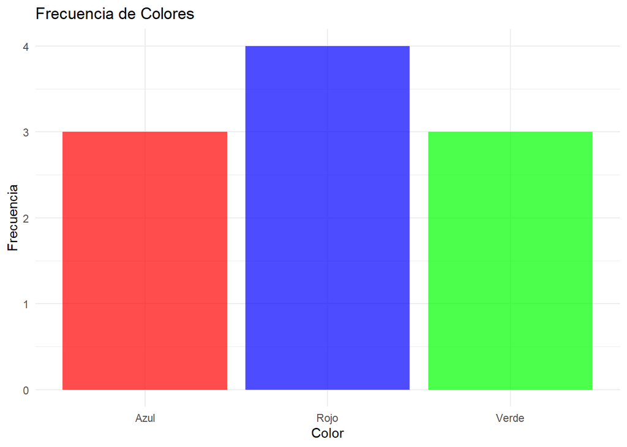

```r
# Crear datos de ejemplo
# CAMBIAR: Reemplaza estos valores por tus categorías
colores <- c("Rojo", "Azul", "Verde", "Rojo", "Azul", "Rojo", "Verde", "Verde", "Azul", "Rojo")  # <<< CAMBIAR
df_colores <- data.frame(color = colores)  # <<< CAMBIAR: df_colores y color

# Gráfico de barras simple
# CAMBIAR: df_colores por tu dataframe, color por tu variable
ggplot(df_colores, aes(x = color)) +  # <<< CAMBIAR: df_colores y color
  geom_bar(fill = c("red", "blue", "green"), alpha = 0.7) +
  labs(title = "Frecuencia de Colores",  # <<< CAMBIAR: título
       x = "Color",  # <<< CAMBIAR: etiqueta del eje x
       y = "Frecuencia") +
  theme_minimal()
```

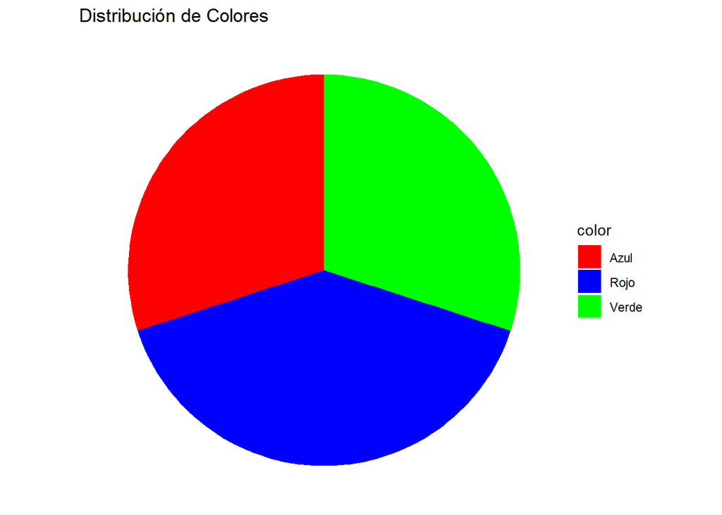

```r
# Gráfico de pastel
# CAMBIAR: df_colores por tu dataframe, color por tu variable
conteo_colores <- df_colores %>%  # <<< CAMBIAR: conteo_colores y df_colores
  count(color) %>%  # <<< CAMBIAR: color
  mutate(porcentaje = n/sum(n)*100)

ggplot(conteo_colores, aes(x = "", y = n, fill = color)) +  # <<< CAMBIAR: conteo_colores y color
  geom_bar(stat = "identity", width = 1) +
  coord_polar("y", start = 0) +
  scale_fill_manual(values = c("red", "blue", "green")) +
  labs(title = "Distribución de Colores") +  # <<< CAMBIAR: título
  theme_void()
```

## 2. Para datos numéricos agrupados (Variable Cuantitativa)

### Tabla de Frecuencia - Histograma

**Cuándo usar:** Cuando los números están en rangos (como edades 20-30, 30-40) o quieres ver la distribución de datos continuos.

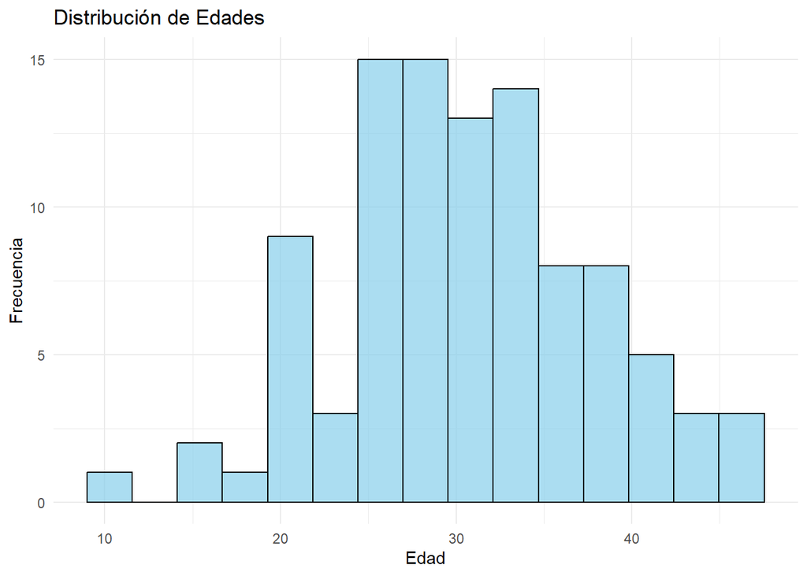

```r
# Crear datos de ejemplo - edades
set.seed(123)
edades <- rnorm(100, mean = 30, sd = 8)  # <<< CAMBIAR: edades
df_edades <- data.frame(edad = edades)  # <<< CAMBIAR: df_edades y edad

# Histograma
# CAMBIAR: df_edades por tu dataframe, edad por tu variable numérica
ggplot(df_edades, aes(x = edad)) +  # <<< CAMBIAR: df_edades y edad
  geom_histogram(bins = 15, fill = "skyblue", color = "black", alpha = 0.7) +
  labs(title = "Distribución de Edades",  # <<< CAMBIAR: título
       x = "Edad",  # <<< CAMBIAR: etiqueta del eje x
       y = "Frecuencia") +
  theme_minimal()
```

## 3. Para comparar dos variables categóricas

### Tabla de Asociación - Barras compuestas o superpuestas

**Cuándo usar:** Para comparar dos tipos de categorías (como género vs profesión).

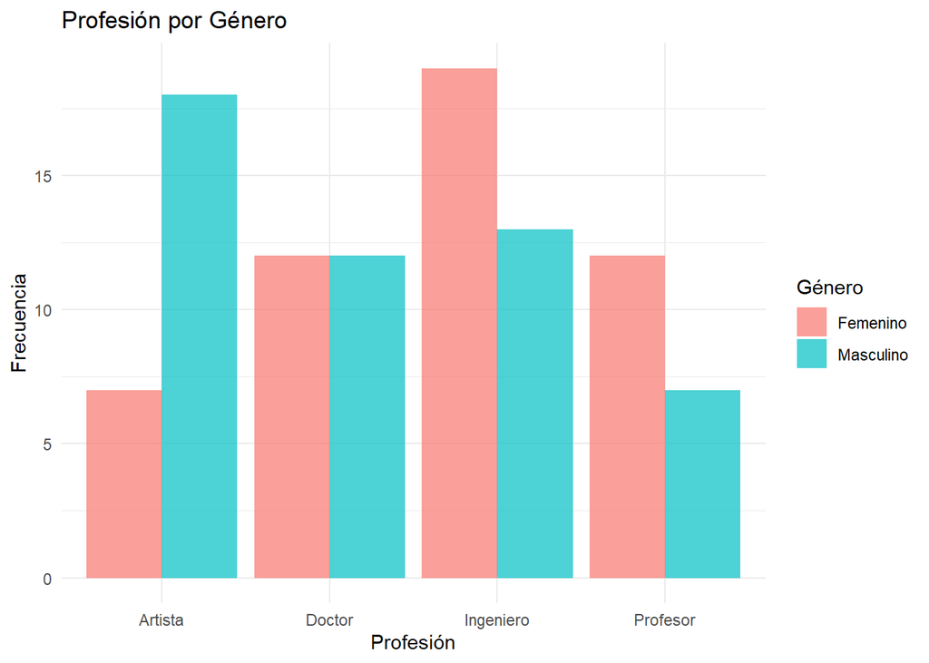

```r
# Crear datos de ejemplo
genero <- rep(c("Masculino", "Femenino"), each = 50)  # <<< CAMBIAR: genero y valores
profesion <- sample(c("Ingeniero", "Doctor", "Profesor", "Artista"), 100, replace = TRUE)  # <<< CAMBIAR: profesion y valores
df_asociacion <- data.frame(genero = genero, profesion = profesion)  # <<< CAMBIAR: df_asociacion, genero, profesion

# Barras compuestas (agrupadas)
# CAMBIAR: df_asociacion, profesion, genero por tus variables
ggplot(df_asociacion, aes(x = profesion, fill = genero)) +  # <<< CAMBIAR: df_asociacion, profesion, genero
  geom_bar(position = "dodge", alpha = 0.7) +
  labs(title = "Profesión por Género",  # <<< CAMBIAR: título
       x = "Profesión",  # <<< CAMBIAR: etiqueta del eje x
       y = "Frecuencia",
       fill = "Género") +  # <<< CAMBIAR: etiqueta de la leyenda
  theme_minimal()
```

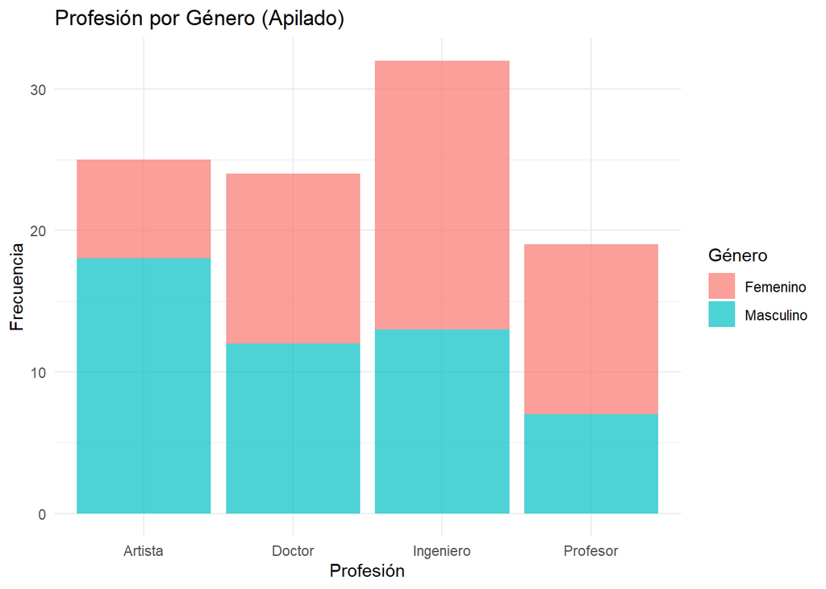

```r
# Barras superpuestas (apiladas)
# CAMBIAR: df_asociacion, profesion, genero por tus variables
ggplot(df_asociacion, aes(x = profesion, fill = genero)) +  # <<< CAMBIAR: df_asociacion, profesion, genero
  geom_bar(position = "stack", alpha = 0.7) +
  labs(title = "Profesión por Género (Apilado)",  # <<< CAMBIAR: título
       x = "Profesión",  # <<< CAMBIAR: etiqueta del eje x
       y = "Frecuencia",
       fill = "Género") +  # <<< CAMBIAR: etiqueta de la leyenda
  theme_minimal()
```

## 4. Para una variable categórica y una cuantitativa discreta

### Barras compuestas/superpuestas

**Cuándo usar:** Cuando tienes categorías con números separados (como ventas por mes).

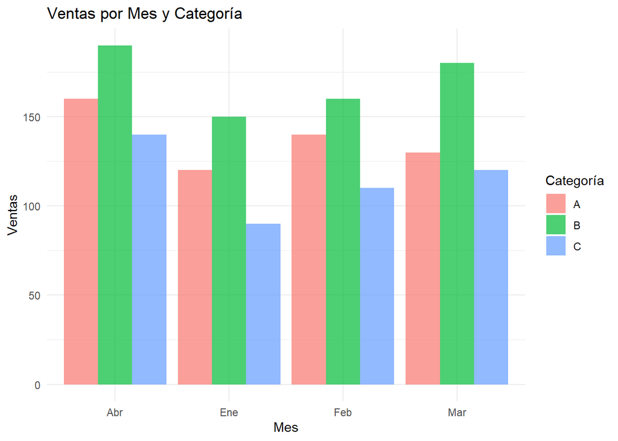

```r
# Crear datos de ejemplo - ventas por mes y categoría
meses <- rep(c("Ene", "Feb", "Mar", "Abr"), each = 3)  # <<< CAMBIAR: meses y valores
categoria <- rep(c("A", "B", "C"), 4)  # <<< CAMBIAR: categoria y valores
ventas <- c(120, 150, 90, 140, 160, 110, 130, 180, 120, 160, 190, 140)  # <<< CAMBIAR: ventas
df_ventas <- data.frame(mes = meses, categoria = categoria, ventas = ventas)  # <<< CAMBIAR: df_ventas, mes, categoria, ventas

# Barras compuestas
# CAMBIAR: df_ventas, mes, ventas, categoria por tus variables
ggplot(df_ventas, aes(x = mes, y = ventas, fill = categoria)) +  # <<< CAMBIAR: df_ventas, mes, ventas, categoria
  geom_bar(stat = "identity", position = "dodge", alpha = 0.7) +
  labs(title = "Ventas por Mes y Categoría",  # <<< CAMBIAR: título
       x = "Mes",  # <<< CAMBIAR: etiqueta del eje x
       y = "Ventas",  # <<< CAMBIAR: etiqueta del eje y
       fill = "Categoría") +  # <<< CAMBIAR: etiqueta de la leyenda
  theme_minimal()
```

## 5. Para una variable categórica y una cuantitativa continua

### Polígono de Frecuencia o Box Plot

**Cuándo usar:** Para una categoría con números continuos (como temperatura a lo largo del día).

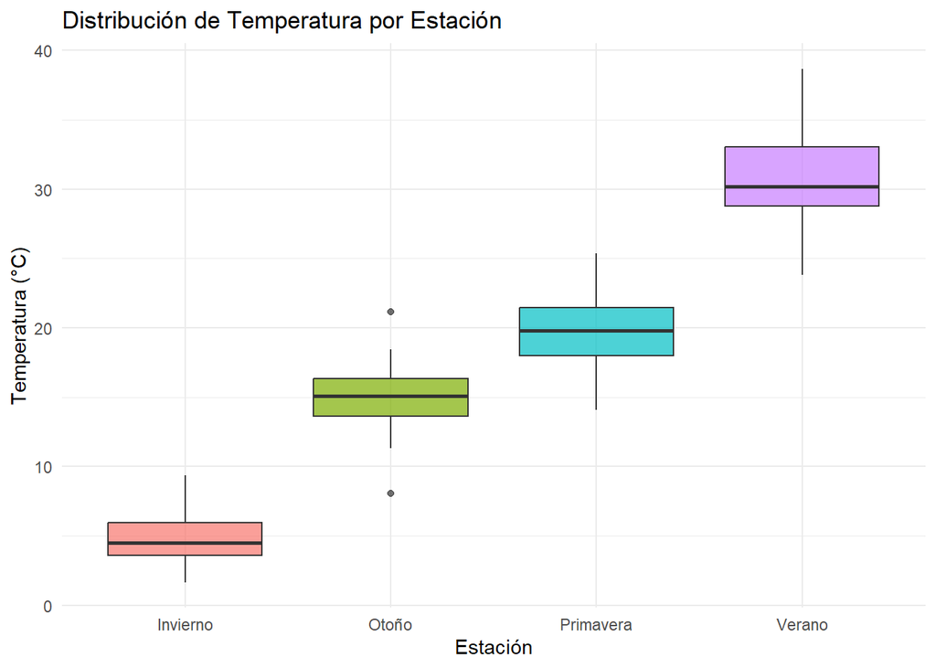

```r
# Crear datos de ejemplo - temperatura por estación
set.seed(123)
estacion <- rep(c("Primavera", "Verano", "Otoño", "Invierno"), each = 30)  # <<< CAMBIAR: estacion y valores
temperatura <- c(rnorm(30, 20, 3), rnorm(30, 30, 4), rnorm(30, 15, 3), rnorm(30, 5, 2))  # <<< CAMBIAR: temperatura
df_temp <- data.frame(estacion = estacion, temperatura = temperatura)  # <<< CAMBIAR: df_temp, estacion, temperatura

# Box Plot
# CAMBIAR: df_temp, estacion, temperatura por tus variables
ggplot(df_temp, aes(x = estacion, y = temperatura, fill = estacion)) +  # <<< CAMBIAR: df_temp, estacion, temperatura
  geom_boxplot(alpha = 0.7) +
  labs(title = "Distribución de Temperatura por Estación",  # <<< CAMBIAR: título
       x = "Estación",  # <<< CAMBIAR: etiqueta del eje x
       y = "Temperatura (°C)") +  # <<< CAMBIAR: etiqueta del eje y
  theme_minimal() +
  theme(legend.position = "none")
```

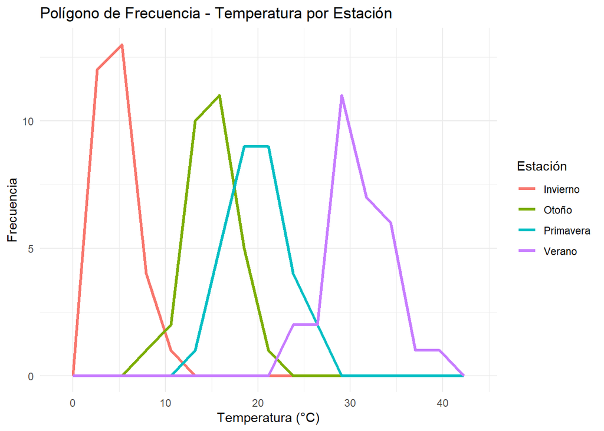

```r
# Polígono de frecuencia (usando geom_freqpoly)
# CAMBIAR: df_temp, temperatura, estacion por tus variables
ggplot(df_temp, aes(x = temperatura, color = estacion)) +  # <<< CAMBIAR: df_temp, temperatura, estacion
  geom_freqpoly(bins = 15, size = 1.2) +
  labs(title = "Polígono de Frecuencia - Temperatura por Estación",  # <<< CAMBIAR: título
       x = "Temperatura (°C)",  # <<< CAMBIAR: etiqueta del eje x
       y = "Frecuencia",
       color = "Estación") +  # <<< CAMBIAR: etiqueta de la leyenda
  theme_minimal()
```

## 6. Para dos variables cuantitativas

### Diagrama de Puntos (Scatter Plot)

**Cuándo usar:** Cuando quieres ver la relación entre dos números (como altura vs peso).

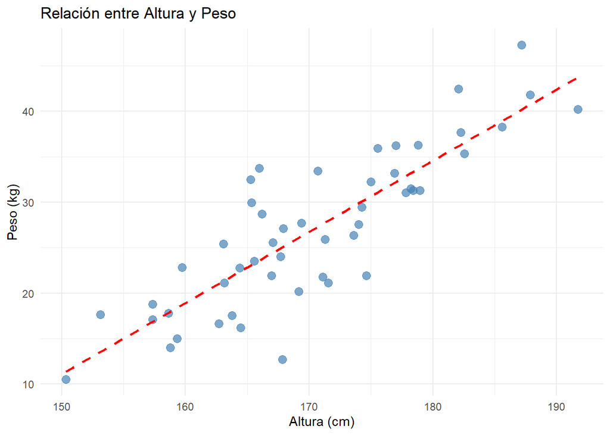

```r
# Crear datos de ejemplo - altura vs peso
set.seed(123)
altura <- rnorm(50, 170, 10)  # <<< CAMBIAR: altura
peso <- 0.8 * altura + rnorm(50, -110, 5)  # <<< CAMBIAR: peso (ajustar fórmula según tus datos)
df_scatter <- data.frame(altura = altura, peso = peso)  # <<< CAMBIAR: df_scatter, altura, peso

# Diagrama de puntos
# CAMBIAR: df_scatter, altura, peso por tus variables
ggplot(df_scatter, aes(x = altura, y = peso)) +  # <<< CAMBIAR: df_scatter, altura, peso
  geom_point(color = "steelblue", size = 3, alpha = 0.7) +
  geom_smooth(method = "lm", se = FALSE, color = "red", linetype = "dashed") +
  labs(title = "Relación entre Altura y Peso",  # <<< CAMBIAR: título
       x = "Altura (cm)",  # <<< CAMBIAR: etiqueta del eje x
       y = "Peso (kg)") +  # <<< CAMBIAR: etiqueta del eje y
  theme_minimal()
```

## 🔧 GUÍA RÁPIDA DE PERSONALIZACIÓN

### Para adaptar a tus datos:

**1. Busca los comentarios `# <<< CAMBIAR` y modifica:** - Nombres de dataframes: `df_colores`, `df_edades`, etc. - Nombres de variables: `color`, `edad`, `genero`, etc. - Títulos y etiquetas en `labs()`

**2. Si usas tus propios datos, reemplaza la sección de creación de datos con:**

```r
# Cargar tus datos
tu_dataframe <- read.csv("tu_archivo.csv")
# o usa tu dataframe existente directamente
```

**3. Ejemplo de personalización:**

```r
# Original:
ggplot(df_colores, aes(x = color)) +

# Personalizado:
ggplot(mis_datos, aes(x = marca_producto)) +
```

## 7. Análisis Univariado - Una sola variable

### Para análisis de una sola variable

**Cuándo usar:** Cuando solo quieres analizar el comportamiento de UNA variable por sí sola.

```r
# Para variable categórica - Tabla de frecuencias
mi_variable <- c("A", "B", "C", "A", "B", "A", "C", "C", "B", "A")  # <<< CAMBIAR: mi_variable
df_univariado <- data.frame(categoria = mi_variable)  # <<< CAMBIAR: df_univariado y categoria

# Tabla de frecuencias
tabla_freq <- table(df_univariado$categoria)  # <<< CAMBIAR: df_univariado y categoria
print("Tabla de frecuencias:")
```

```
## [1] "Tabla de frecuencias:"
```

```r
print(tabla_freq)
```

```
##
## A B C
## 4 3 3
```

```r
# Tabla de frecuencias relativas (porcentajes)
tabla_freq_rel <- prop.table(tabla_freq) * 100
print("Tabla de frecuencias relativas (%):")
```

```
## [1] "Tabla de frecuencias relativas (%):"
```

```r
print(round(tabla_freq_rel, 2))
```

```
##
##  A  B  C
## 40 30 30
```

```r
# Para variable numérica - Estadísticas descriptivas
set.seed(123)
mi_variable_num <- rnorm(50, mean = 25, sd = 5)  # <<< CAMBIAR: mi_variable_num
df_num_univariado <- data.frame(valor = mi_variable_num)  # <<< CAMBIAR: df_num_univariado y valor

# Estadísticas descriptivas
print("Estadísticas descriptivas:")
```

```
## [1] "Estadísticas descriptivas:"
```

```r
summary(df_num_univariado$valor)  # <<< CAMBIAR: df_num_univariado y valor
```

```
##    Min. 1st Qu.  Median    Mean 3rd Qu.    Max.
##   15.17   22.20   24.64   25.17   28.49   35.84
```

```r
# Estadísticas adicionales
print(paste("Desviación estándar:", round(sd(df_num_univariado$valor), 2)))  # <<< CAMBIAR: df_num_univariado y valor
```

```
## [1] "Desviación estándar: 4.63"
```

```r
print(paste("Varianza:", round(var(df_num_univariado$valor), 2)))  # <<< CAMBIAR: df_num_univariado y valor
```

```
## [1] "Varianza: 21.43"
```

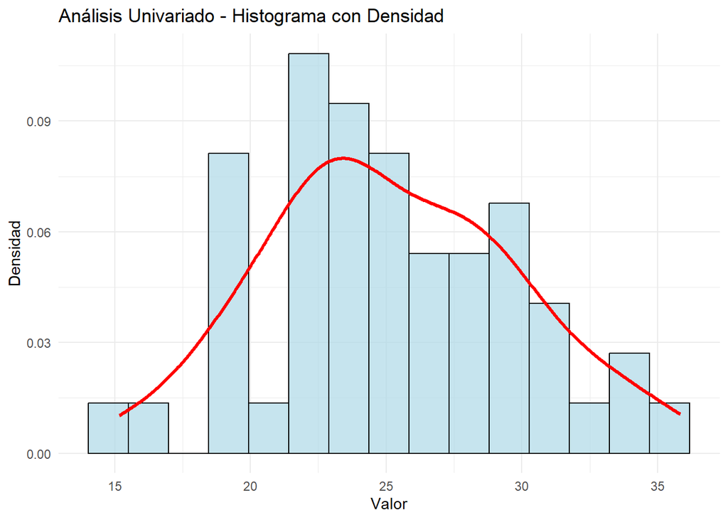

```r
# Gráficos para análisis univariado de variable numérica
# Histograma con línea de densidad
ggplot(df_num_univariado, aes(x = valor)) +  # <<< CAMBIAR: df_num_univariado y valor
  geom_histogram(aes(y = ..density..), bins = 15, fill = "lightblue",
                 color = "black", alpha = 0.7) +
  geom_density(color = "red", size = 1.2) +
  labs(title = "Análisis Univariado - Histograma con Densidad",  # <<< CAMBIAR: título
       x = "Valor",  # <<< CAMBIAR: etiqueta del eje x
       y = "Densidad") +
  theme_minimal()
```

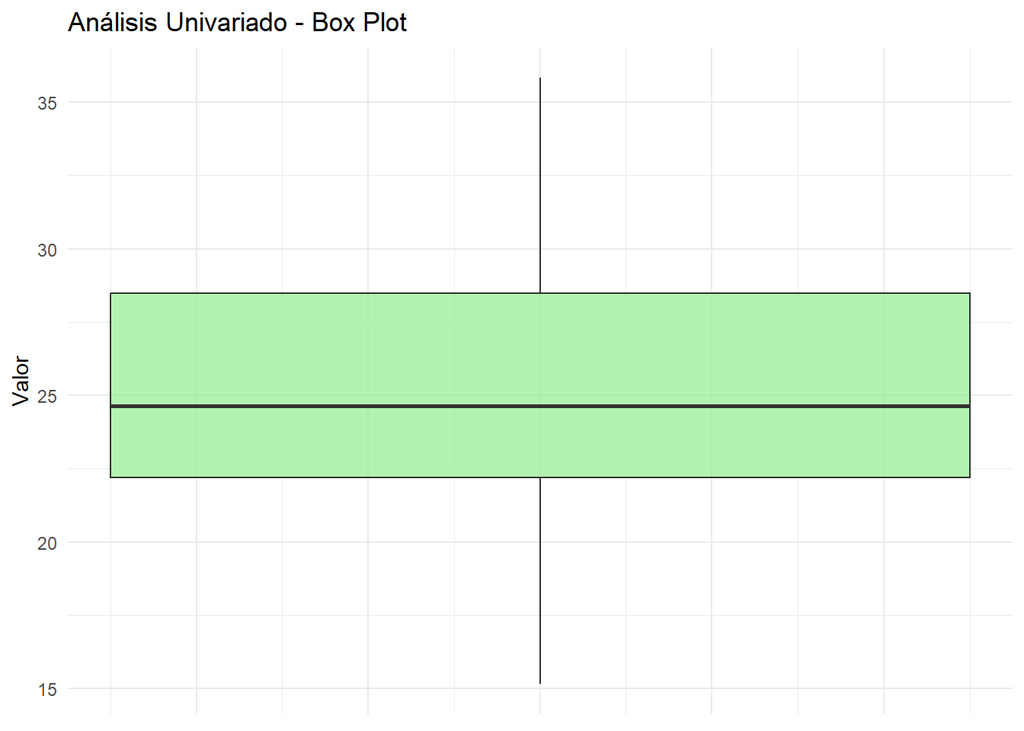

```r
# Box plot univariado (para detectar outliers)
ggplot(df_num_univariado, aes(y = valor)) +  # <<< CAMBIAR: df_num_univariado y valor
  geom_boxplot(fill = "lightgreen", alpha = 0.7, width = 0.5) +
  labs(title = "Análisis Univariado - Box Plot",  # <<< CAMBIAR: título
       y = "Valor") +  # <<< CAMBIAR: etiqueta del eje y
  theme_minimal() +
  theme(axis.text.x = element_blank(),
        axis.ticks.x = element_blank())
```

## Resumen - Regla Simple

- **¿Una sola variable categórica?** → Tabla de frecuencias + Barras o pastel
- **¿Una sola variable numérica?** → Estadísticas descriptivas + Histograma + Box plot
- **¿Solo categorías (dos o más)?** → Barras o pastel
- **¿Solo números continuos?** → Histograma
- **¿Quieres comparar grupos?** → Barras compuestas
- **¿Relación entre dos números?** → Puntos (scatter plot)
- **¿Distribución por grupos?** → Box plot

*Esta guía te ayudará a elegir el gráfico correcto según tus datos. ¡Solo busca los comentarios # <<< CAMBIAR y modifica las variables!*